# Analyst Intern, Data Science & Solutions Project

Judson Murray

08/18/23

# Introduction

The purpose of this project is to gauge your technical skills and problem solving ability by working through something similar to a real NBA data science project. You will work your way through this R Markdown document, answering questions as you go along. Please begin by adding your name to the “author” key in the YAML header. When you’re finished with the document, come back and type your answers into the answer key at the top. Please leave all your work below and have your answers where indicated below as well. Please note that we will be reviewing your code so make it clear, concise and avoid long printouts. Feel free to add in as many new code chunks as you’d like.

Remember that we will be grading the quality of your code and visuals alongside the correctness of your answers. Please try to use the tidyverse as much as possible (instead of base R and explicit loops.)

**Note:**

**Throughout this document, any `season` column represents the year each season started. For example, the 2015-16 season will be in the dataset as 2015. For most of the rest of the project, we will refer to a season by just this number (e.g. 2015) instead of the full text (e.g. 2015-16).**

# Answers

## Part 1

**Question 1:**

1st Team: 22.63 points per game  
2nd Team: 20.03 points per game  
3rd Team: 17.94 points per game  
All-Star: 19.23 points per game

**Question 2:** 5.93 Years

**Question 3:**

Elite: 2 players.  
All-Star: 1 players.  
Starter: 11 players.  
Rotation: 7 players.  
Roster: 15 players.  
Out of League: 37 players.

**Open Ended Modeling Question:** Please show your work and leave all responses below in the document.

## Part 2

**Question 1:** 28.9%  
**Question 2:** Written question, put answer below in the document.  
**Question 3:** Written question, put answer below in the document.

# Setup and Data

```r
library(tidyverse)
# Note, you will likely have to change these paths. If your data is in the same folder as this project,
# the paths will likely be fixed for you by deleting ../../Data/awards_project/ from each string.
awards <- read_csv("awards_data.csv")
player_data <- read_csv("player_stats.csv")
team_data <- read_csv("team_stats.csv")
rebounding_data <- read_csv("team_rebounding_data_22.csv")
```

## Part 1 – Awards

In this section, you’re going to work with data relating to player awards and statistics. You’ll start with some data manipulation questions and work towards building a model to predict broad levels of career success.

### Question 1

**QUESTION:** What is the average number of points per game for players in the 2007-2021 seasons who won All NBA First, Second, and Third teams (**not** the All Defensive Teams), as well as for players who were in the All-Star Game (**not** the rookie all-star game)?

```r
# Here and for all future questions, feel free to add as many code chunks as you like. Do NOT put echo = F though, we'll want to see your code.


# First, I wrote a functiom to find the points per game of a specified vector of
# players using the player_data dataset.

calculate_ppg <- function(team_vector, player_data) {
  length_of_team <- length(team_vector)
  ppg_team <- numeric(length_of_team)

  for (i in 1:length_of_team) {
    element <- team_vector[i]


    ppg_team[i] <- sum(player_data$points[player_data$nbapersonid == element]) /
                   sum(player_data$games[player_data$nbapersonid == element])
  }

  return(ppg_team)
}

# using function to calculate the average points per game of the players
# in various all nba teams from 2007-2021

first_team = awards$nbapersonid[which(awards$`All NBA First Team` == 1)]
ppg_first = calculate_ppg(first_team, player_data)
print(mean(ppg_first))
```

```
## [1] 22.63266
```

```r
# avg ppg for players who earned 1st team all nba is 22.63266 ppg


second_team = awards$nbapersonid[which(awards$`All NBA Second Team` == 1)]
ppg_second = calculate_ppg(second_team, player_data)
print(mean(ppg_second))
```

```
## [1] 20.03126
```

```r
# avg ppg for players who earned 2nd team all nba is 20.03126 ppg

third_team = awards$nbapersonid[which(awards$`All NBA Third Team` == 1)]
ppg_third = calculate_ppg(third_team, player_data)
print(mean(ppg_third))
```

```
## [1] 17.93628
```

```r
# avg ppg for players who earned 3rd team all nba is 17.93628 ppg

all_star = awards$nbapersonid[which(awards$all_star_game == T)]
ppg_ASG = calculate_ppg(all_star, player_data)
print(mean(ppg_ASG))
```

```
## [1] 19.22786
```

```r
# avg ppg for players who earned All Star team is 19.22786 ppg
```

**ANSWER 1:**

1st Team: 22.63 points per game  
2nd Team: 20.03 points per game  
3rd Team: 17.94 points per game  
All-Star: 19.23 points per game

### Question 2

**QUESTION:** What was the average number of years of experience in the league it takes for players to make their first All NBA Selection (1st, 2nd, or 3rd team)? Please limit your sample to players drafted in 2007 or later who did eventually go on to win at least one All NBA selection. For example:

- Luka Doncic is in the dataset as 2 years. He was drafted in 2018 and won his first All NBA award in 2019 (which was his second season).
- LeBron James is not in this dataset, as he was drafted prior to 2007.
- Lu Dort is not in this dataset, as he has not received any All NBA honors.

```r
# first filter the data for players drafted in or after 2007.
filtered_data <- player_data %>%
   filter(draftyear >= 2007)

# now, merge the filtered data with the awards data based on NBApersonID, since
# this is the only like column between the two datasets

merged_data <- merge(filtered_data, awards, by = "nbapersonid")

# next, filter the merged data to observations where the player was selected
# for one of the All NBA teams (using the | operator for filtering)

first_all_nba <- merged_data %>%
  filter(`All NBA First Team` == 1 | `All NBA Second Team` == 1 | `All NBA Third Team` == 1)

# finally, find the average number of seasons it took a player to be selected
# to an All NBA team by taking the average of all the differences in the year
# players were selected to an All NBA team, and the year they were drafted

# in this case, season.y is the season pertaining to the awards dataset, ie
# the season in which the player was selected to an All NBA team.

avg_no_seasons_allNBA = mean(first_all_nba$season.y - first_all_nba$draftyear)
avg_no_seasons_allNBA
```

```
## [1] 5.928724
```

```r
# average number of years for a player to be selected in an all NBA team, given
# they were drafted in or after 2007 is 5.93 years
```

**ANSWER 2:**

5.93 Years

## Data Cleaning Interlude

You’re going to work to create a dataset with a “career outcome” for each player, representing the highest level of success that the player achieved for **at least two** seasons *after his first four seasons in the league* (examples to follow below!). To do this, you’ll start with single season level outcomes. On a single season level, the outcomes are:

- Elite: A player is “Elite” in a season if he won any All NBA award (1st, 2nd, or 3rd team), MVP, or DPOY in that season.
- All-Star: A player is “All-Star” in a season if he was selected to be an All-Star that season.
- Starter: A player is a “Starter” in a season if he started in at least 41 games in the season OR if he played at least 2000 minutes in the season.
- Rotation: A player is a “Rotation” player in a season if he played at least 1000 minutes in the season.
- Roster: A player is a “Roster” player in a season if he played at least 1 minute for an NBA team but did not meet any of the above criteria.
- Out of the League: A player is “Out of the League” if he is not in the NBA in that season.

We need to make an adjustment for determining Starter/Rotation qualifications for a few seasons that didn’t have 82 games per team. Assume that there were 66 possible games in the 2011 lockout season and 72 possible games in each of the 2019 and 2020 seasons that were shortened due to covid. Specifically, if a player played 900 minutes in 2011, he **would** meet the rotation criteria because his final minutes would be considered to be 900 * (82/66) = 1118. Please use this math for both minutes and games started, so a player who started 38 games in 2019 or 2020 would be considered to have started 38 * (82/72) = 43 games, and thus would qualify for starting 41. Any answers should be calculated assuming you round the multiplied values to the nearest whole number.

Note that on a season level, a player’s outcome is the highest level of success he qualifies for in that season. Thus, since Shai Gilgeous-Alexander was both All-NBA 1st team and an All-Star last year, he would be considered to be “Elite” for the 2022 season, but would still qualify for a career outcome of All-Star if in the rest of his career he made one more All-Star game but no more All-NBA teams. Note this is a hypothetical, and Shai has not yet played enough to have a career outcome.

Examples:

- A player who enters the league as a rookie and has season outcomes of Roster (1), Rotation (2), Rotation (3), Roster (4), Roster (5), Out of the League (6+) would be considered “Out of the League,” because after his first four seasons, he only has a single Roster year, which does not qualify him for any success outcome.
- A player who enters the league as a rookie and has season outcomes of Roster (1), Rotation (2), Starter (3), Starter (4), Starter (5), Starter (6), All-Star (7), Elite (8), Starter (9) would be considered “All-Star,” because he had at least two seasons after his first four at all-star level of production or higher.
- A player who enters the league as a rookie and has season outcomes of Roster (1), Rotation (2), Starter (3), Starter (4), Starter (5), Starter (6), Rotation (7), Rotation (8), Roster (9) would be considered a “Starter” because he has two seasons after his first four at a starter level of production.

### Question 3

**QUESTION:** There are 73 players in the `player_data` dataset who have 2010 listed as their draft year. How many of those players have a **career** outcome in each of the 6 buckets?

```r
# first, I create a vector to subset players drafted in 2010

drafted_2010 = player_data[which(player_data$draftyear == 2010),]





classify_players <- function(player_data, awards) {
  # Filter players who have completed at least 4 seasons since their draft year
  filtered_data <- player_data %>%
    group_by(nbapersonid, player, draftyear) %>%
    filter(season - draftyear >= 4)

  # Defining adjustments for games and minutes in specific seasons
  game_adjustment <- function(season) {
    ifelse(season == 2011, 82/66, ifelse(season %in% c(2019, 2020), 82/72, 1))
                                      }


  # Creating adjusted binary indicators for different scenarios in order to
  # classify players
  filtered_data <- filtered_data %>%
    mutate(
      has_min_1 = ifelse(mins >= 1, 1, 0),

      is_rotation_season = ifelse(mins * game_adjustment(season) >= 1000 & mins * game_adjustment(season) < 2000 & games_start * game_adjustment(season) < 41, 1, 0),

      is_season_started = ifelse(games_start * game_adjustment(season) >= 41 | mins * game_adjustment(season) > 2000, 1, 0)

           )



  # Count the number of times a player has been on an All-NBA team, been in an
  # all star game, been a starter for a season, been a rotation player, or been
  # a roster player
  players <- filtered_data %>%
    left_join(awards, by = c("nbapersonid", "season")) %>%
    group_by(nbapersonid, player) %>%
    summarize(

       total_all_nba = sum(`All NBA First Team` + `All NBA Second Team` + `All NBA Third Team`, na.rm = TRUE),

       total_all_star = sum(all_star_game, na.rm = T),

       seasons_started = sum(is_season_started),  # Count seasons with season_started

       rotation_seasons = sum(is_rotation_season),  # Count seasons with rotation_season

       roster_seasons = sum(has_min_1 == 1 & is_rotation_season == 0 & is_season_started == 0, na.rm = TRUE)

    )

  # Classify players according to their met criteria
  players$classification <- ifelse(players$total_all_nba >= 2,
    "Elite",
    ifelse(players$total_all_star >= 2,
           "All Star",
           ifelse(players$seasons_started >= 2,
                  "Starter",
                  ifelse(players$rotation_seasons >= 2,
                         "Rotation",
                         ifelse(players$roster_seasons >=2,
                                "Roster", "Out Of League")))



           )
  )

  return(players)
}

career_classification_2010 = classify_players(drafted_2010, awards)
career_classification_2010[which(career_classification_2010$classification == "Elite"),]
```

```
## # A tibble: 2 × 8
## # Groups:   nbapersonid [2]
##   nbapersonid player           total_all_nba total_all_star seasons_started
##         <dbl> <chr>                    <dbl>          <int>           <dbl>
## 1      202326 DeMarcus Cousins             2              5               4
## 2      202331 Paul George                  4              5               6
## # ℹ 3 more variables: rotation_seasons <dbl>, roster_seasons <int>,
## #   classification <chr>
```

```r
# 2 players are classified as elite

career_classification_2010[which(career_classification_2010$classification == "All Star"),]
```

```
## # A tibble: 1 × 8
## # Groups:   nbapersonid [1]
##   nbapersonid player    total_all_nba total_all_star seasons_started
##         <dbl> <chr>             <dbl>          <int>           <dbl>
## 1      202322 John Wall             1              4               5
## # ℹ 3 more variables: rotation_seasons <dbl>, roster_seasons <int>,
## #   classification <chr>
```

```r
# 1 player is classified as All Star

career_classification_2010[which(career_classification_2010$classification == "Starter"),]
```

```
## # A tibble: 11 × 8
## # Groups:   nbapersonid [11]
##    nbapersonid player            total_all_nba total_all_star seasons_started
##          <dbl> <chr>                     <dbl>          <int>           <dbl>
##  1      202323 Evan Turner                   0              0               3
##  2      202324 Derrick Favors                0              0               5
##  3      202328 Greg Monroe                   0              0               2
##  4      202329 Al-Farouq Aminu               0              0               3
##  5      202330 Gordon Hayward                0              1               6
##  6      202335 Patrick Patterson             0              0               2
##  7      202339 Eric Bledsoe                  0              0               6
##  8      202340 Avery Bradley                 0              0               6
##  9      202355 Hassan Whiteside              0              0               5
## 10      202357 Nemanja Bjelica               0              0               2
## 11      202397 Ish Smith                     0              0               3
## # ℹ 3 more variables: rotation_seasons <dbl>, roster_seasons <int>,
## #   classification <chr>
```

```r
# 11 players classified as Starter

career_classification_2010[which(career_classification_2010$classification == "Rotation"),]
```

```
## # A tibble: 7 × 8
## # Groups:   nbapersonid [7]
##   nbapersonid player           total_all_nba total_all_star seasons_started
##         <dbl> <chr>                    <dbl>          <int>           <dbl>
## 1      202325 Wesley Johnson               0              0               1
## 2      202334 Ed Davis                     0              0               0
## 3      202344 Trevor Booker                0              0               1
## 4      202362 Lance Stephenson             0              0               0
## 5      202388 Donald Sloan                 0              0               0
## 6      202391 Jeremy Lin                   0              0               1
## 7      202498 Lance Thomas                 0              0               0
## # ℹ 3 more variables: rotation_seasons <dbl>, roster_seasons <int>,
## #   classification <chr>
```

```r
# 7 players classified as rotation

career_classification_2010[which(career_classification_2010$classification == "Roster"),]
```

```
## # A tibble: 15 × 8
## # Groups:   nbapersonid [15]
##    nbapersonid player           total_all_nba total_all_star seasons_started
##          <dbl> <chr>                    <dbl>          <int>           <dbl>
##  1      202327 Ekpe Udoh                    0              0               0
##  2      202332 Cole Aldrich                 0              0               0
##  3      202336 Larry Sanders                0              0               0
##  4      202337 Luke Babbitt                 0              0               1
##  5      202338 Kevin Séraphin               0              0               0
##  6      202343 Elliot Williams              0              0               0
##  7      202347 Quincy Pondexter             0              0               0
##  8      202348 Jordan Crawford              0              0               0
##  9      202349 Greivis Vasquez              0              0               0
## 10      202379 Jeremy Evans                 0              0               0
## 11      202407 Elijah Millsap               0              0               0
## 12      202620 Arinze Onuaku                0              0               0
## 13      203144 Alexey Shved                 0              0               0
## 14     1626246 Boban Marjanovic             0              0               0
## 15     1626780 Jonathan Gibson              0              0               0
## # ℹ 3 more variables: rotation_seasons <dbl>, roster_seasons <int>,
## #   classification <chr>
```

```r
# 15 players classified as Roster

career_classification_2010[which(career_classification_2010$classification == "Out Of League"),]
```

```
## # A tibble: 8 × 8
## # Groups:   nbapersonid [8]
##   nbapersonid player              total_all_nba total_all_star seasons_started
##         <dbl> <chr>                       <dbl>          <int>           <dbl>
## 1      202333 Xavier Henry                    0              0               0
## 2      202341 James Anderson                  0              0               0
## 3      202353 Tibor Pleiss                    0              0               0
## 4      202361 Landry Fields                   0              0               0
## 5      202366 Jerome Jordan                   0              0               0
## 6      202412 Manny Harris                    0              0               0
## 7      203545 Miroslav Raduljica              0              0               0
## 8      203565 Patrick Christopher             0              0               0
## # ℹ 3 more variables: rotation_seasons <dbl>, roster_seasons <int>,
## #   classification <chr>
```

```r
# 37 players were classified as Out of League (some not shown in the output since
# they may not have played for 4 years after being drafted)
```

**ANSWER 3:**

Elite: 2 players.  
All-Star: 1 players.  
Starter: 11 players.  
Rotation: 7 players.  
Roster: 15 players.  
Out of League: 37 players.

### Open Ended Modeling Question

In this question, you will work to build a model to predict a player’s career outcome based on information up through the first four years of his career.

This question is intentionally left fairly open ended, but here are some notes and specifications.

1. We know modeling questions can take a long time, and that qualified candidates will have different levels of experience with “formal” modeling. Don’t be discouraged. It’s not our intention to make you spend excessive time here. If you get your model to a good spot but think you could do better by spending a lot more time, you can just write a bit about your ideas for future improvement and leave it there. Further, we’re more interested in your thought process and critical thinking than we are in specific modeling techniques. Using smart features is more important than using fancy mathematical machinery, and a successful candidate could use a simple regression approach.
2. You may use any data provided in this project, but please do not bring in any external sources of data. Note that while most of the data provided goes back to 2007, All NBA and All Rookie team voting is only included back to 2011.
3. A player needs to complete at least three additional seasons after their first four to be considered as having a distinct career outcome for our dataset. (We are using 3+ instead of 2+ just to give each player a little more time to accumulate high level seasons before we classify his career). Because the dataset in this project ends in 2021, this means that a player would need to have had the chance to play in the ’21, ’20, and ’19 seasons after his first four years, and thus his first four years would have been ’18, ’17, ’16, and ’15. **For this reason, limit your training data to players who were drafted in or before the 2015 season.** Karl-Anthony Towns was the #1 pick in that season.
4. Once you build your model, predict on all players who were drafted in 2018-2021 (They have between 1 and 4 seasons of data available and have not yet started accumulating seasons that inform their career outcome).
5. You can predict a single career outcome for each player, but it’s better if you can predict the probability that each player falls into each outcome bucket.
6. Include, as part of your answer:
- A brief written overview of how your model works, targeted towards a decision maker in the front office without a strong statistical background.
- What you view as the strengths and weaknesses of your model.
- How you’d address the weaknesses if you had more time and or more data.
- A ggplot or ggplotly visualization highlighting some part of your modeling process, the model itself, or your results.
- Your predictions for Shai Gilgeous-Alexander, Zion Williamson, James Wiseman, and Josh Giddey.
- (Bonus!) An html table (for example, see the package `reactable`) containing all predictions for the players drafted in 2019-2021.

OVERVIEW: STRENGTHS AND WEAKNESSES

After filtering the player data to get a subset of players that were drafted in or before 2015, my modeling approach was to first use a function called “perform_classification” that uses the data from the awards and player_data datasets in order to define binary indicators for number of rotation seasons, number of roster seasons, and number of seasons started based on various metrics, including the amount of minutes played and games started across seasons for each player observation. I then used these indicators to assign the observations in my subset several new columns that would be used as features for my model, such as the total number of all star seasons a player had, as well as the total number of “roster seasons” a player recorded (according to the definition given in the problem). Because of this I felt that data pre-processing was an apparent strength to my modeling process.

Next, I used a Random Forest classification method in order to perform the classification predictions. I chose this model because it responds well to relationships between features for which there are several in this case (minutes played and games played for example), and because the randomForest method in the R randomForest package accepts many different data types as inputs. For this reason, I felt that method selection was one of the strengths to my approach.

This approach then involved a train/test split for the data to use in the model training, as well as a selection of model features that I felt would be most important for informing the model while also avoiding over fitting. Upon testing my predictions on the test data, my model resulted in an accuracy of .997, which is relatively good.

Some weaknesses that stood out to me with this approach were my feature selection as well as my model tuning methods. If I had more time to perform feature engineering with the provided data, I would consider training my model with different combinations of the available features to attain a better fit. Additionally, if given more time, I would explore a method of hyperparameter tuning, such as grid search, for this model in order to attain better model performance, ensure I am not overfitting the model, and improve efficiency as hyperparameter optimization would ideally allow my model training to converge faster.

```r
library(randomForest)
library(rpart)
library(dplyr)
library(caret)
# filtering to get players drafted in or before 2015, and applying filtering
# similar to that of my classify_players() function to them to get
# classifications for each player.
# also, defining a train/test split to train my model and training a random
# forest model in order to predict the classes of player outcomes.


drafted_2015 = player_data[which(player_data$draftyear <= 2015),]


perform_classification <- function(player_data, awards) {


  # Defining game adjustment function
  game_adjustment <- function(season) {
    ifelse(season == 2011, 82/66, ifelse(season %in% c(2019, 2020), 82/72, 1))
  }

  # Calculating binary indicators for the filtered data
  combined_data <- player_data %>%
    mutate(
      has_min_1 = ifelse(mins >= 1, 1, 0),
      is_rotation_season = ifelse(mins * game_adjustment(season) >= 1000 & mins * game_adjustment(season) < 2000 & games_start * game_adjustment(season) < 41, 1, 0),
      is_season_started = ifelse(games_start * game_adjustment(season) >= 41 | mins * game_adjustment(season) > 2000, 1, 0)
    )

  # Joining player_data with awards
  combined_data <- combined_data %>%
    left_join(awards, by = c("nbapersonid", "season")) %>%
    group_by(nbapersonid, player) %>%
    summarize(
      total_all_nba = sum(`All NBA First Team` + `All NBA Second Team` + `All NBA Third Team`, na.rm = TRUE),
      total_all_star = sum(all_star_game, na.rm = TRUE),
      seasons_started = sum(is_season_started),
      rotation_seasons = sum(is_rotation_season),
      roster_seasons = sum(has_min_1 == 1 & is_rotation_season == 0 & is_season_started == 0, na.rm = TRUE),
      all_nba_first = sum(`All NBA First Team`, na.rm = TRUE),
      all_nba_sec = sum(`All NBA Second Team`, na.rm = TRUE),
      all_nba_third = sum(`All NBA Third Team`, na.rm = TRUE),
      # Include original attributes from player_data and awards_data
      draftyear = first(draftyear),
      games = first(games),
      mins = first(mins),
      games_start = first(games_start)
      # ... include more attributes as needed
    )

  # Defining target labels for career_outcome
  combined_data$career_outcome <- ifelse(
    combined_data$total_all_nba >= 2, "Elite",
    ifelse(combined_data$total_all_star >= 2, "All Star",
           ifelse(combined_data$seasons_started >= 2, "Starter",
                  ifelse(combined_data$rotation_seasons >= 2, "Rotation",
                         ifelse(combined_data$roster_seasons >= 2, "Roster", "Out Of League")))
    )
  )

  return(combined_data)
}

# Call the function with data for players drafted in/before 2015 and awards data
# as arguments
result_data <- perform_classification(drafted_2015, awards)
# defining player name as well as career_outcome as factors so the model
# would be able to recognize them
result_data$player = as.factor(result_data$player)
result_data$career_outcome = as.factor(result_data$career_outcome)


# Splitting data into training and testing sets
set.seed(123) # for reproducibility
train_indices <- sample(nrow(result_data), 0.7 * nrow(result_data))
train_data <- result_data[train_indices, ]
test_data <- result_data[-train_indices, ]



# Selection of features I felt were important for informing the model

features <- c("all_nba_first", "all_nba_sec", "all_nba_third" , "draftyear" ,
  "games" , "mins", "total_all_star", "rotation_seasons", "roster_seasons", "games_start", "seasons_started")




# training the random forest model using the assigned features as well as the
# response variable, career_outcome.

rf_model <- randomForest(career_outcome ~ ., ntree=100, data = train_data[, c(features, "career_outcome")])
# Making predictions on the test data
predictions <- predict(rf_model, newdata = test_data)

# Evaluating the model accuracy
accuracy <- sum(predictions == test_data$career_outcome) / nrow(test_data)
print(paste("Accuracy:", accuracy))
```

```
## [1] "Accuracy: 0.997050147492625"
```

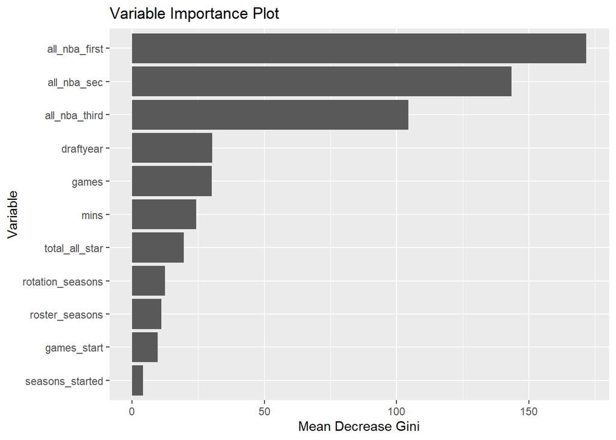

```r
# ggplot visualization of the importance of the variables included in my model:

# here, importance is defined as how much the inclusion of that variable in
# the model decreases the associated gini index score. A high mean decrease in
# gini indicates a more important variable.

var_imp <- as.data.frame(importance(rf_model))
var_imp %>%
  arrange(desc(MeanDecreaseGini)) %>%
  ggplot(aes(x = reorder(rownames(var_imp), MeanDecreaseGini), y = MeanDecreaseGini)) +
  geom_bar(stat = "identity") +
  coord_flip() +
  labs(title = "Variable Importance Plot", x = "Variable", y = "Mean Decrease Gini")
```

```r
# using model to predict the career outcomes of players drafted
# between 2018-2021
# also, applying the modified helper function to the data in order to assign
# attributes to the modified data in order for the model to interpret the
# assigned features.

set.seed(123)

# selecting only those players who were drafted in or after 2018 and assigning
# them season attributes for the model to use with the "perform_classification"
# function from the previous chunk

drafted_2018 = player_data[which(player_data$draftyear >= 2018),]

attributes_2018 = perform_classification(drafted_2018, awards)
# predicting the career outcomes of these players using the model

predictions_new <- predict(rf_model, newdata = attributes_2018)
# Evaluating model accuracy
accuracy_2018 <- sum(predictions_new == attributes_2018$career_outcome) / nrow(attributes_2018)
print(paste("Accuracy:", accuracy_2018))
```

```
## [1] "Accuracy: 0.994949494949495"
```

## Part 2 – Predicting Team Stats

In this section, we’re going to introduce a simple way to predict team offensive rebound percent in the next game and then discuss ways to improve those predictions.

### Question 1

Using the `rebounding_data` dataset, we’ll predict a team’s next game’s offensive rebounding percent to be their average offensive rebounding percent in all prior games. On a single game level, offensive rebounding percent is the number of offensive rebounds divided by their number offensive rebound “chances” (essentially the team’s missed shots). On a multi-game sample, it should be the total number of offensive rebounds divided by the total number of offensive rebound chances.

Please calculate what OKC’s predicted offensive rebound percent is for game 81 in the data. That is, use games 1-80 to predict game 81.

```r
okc_rebounding_data = rebounding_data[which(rebounding_data$team == "OKC"),]
okc_subset = okc_rebounding_data[1:80,]


print(sum(okc_subset$offensive_rebounds)/ sum(okc_subset$off_rebound_chances))
```

```
## [1] 0.2886898
```

**ANSWER 1:**

28.9%

### Question 2

There are a few limitations to the method we used above. For example, if a team has a great offensive rebounder who has played in most games this season but will be out due to an injury for the next game, we might reasonably predict a lower team offensive rebound percent for the next game.

Please discuss how you would think about changing our original model to better account for missing players. You do not have to write any code or implement any changes, and you can assume you have access to any reasonable data that isn’t provided in this project. Try to be clear and concise with your answer.

ANSWER:

In order to account for missing players, you could subtract the missing player’s (or sum of the missing players’) average offensive rebounds statistic multiplied by the number of games prior to the game you are predicting for, from the total number of offensive rebounds you are using in the prediction calculation.

Thus, instead of having the model read: predicted offensive rebounding % = total # of offensive rebounds / total number of chances

your new prediction model would read : predicted offensive rebounding % = ((total # of offensive rebounds) - (players avg. off. rebounds * games played))/ total number of chances

This way, the total number of rebounds for the games played thus far is essentially adjusted to account for the lack of that player (or players), and the prediction will be made as if that player was not included in the rebounding data, and would reflect your team’s predicted offensive rebounding percentage without the missing player in question.

**ANSWER 2:**

### Question 3

In question 2, you saw and discussed how to deal with one weakness of the model. For this question, please write about 1-3 other potential weaknesses of the simple average model you made in question 1 and discuss how you would deal with each of them. You may either explain a weakness and discuss how you’d fix that weakness, then move onto the next issue, or you can start by explaining multiple weaknesses with the original approach and discuss one overall modeling methodology you’d use that gets around most or all of them. Again, you do not need to write any code or implement any changes, and you can assume you have access to any reasonable data that isn’t provided in this project. Try to be clear and concise with your answer.

ANSWER:

Some potential weaknesses that stick out to me regarding the simple average model in question 1 are that this model assumes no variability in team performance or strategy. A team could change their offensive strategy over the course of the season, and this could heavily impact their offensive rebounding performance. Additionally, there could be potential outliers in performance. For instance, if a player records a game with 20 offensive rebounds (very unlikely), it could contribute to skewing the prediction outcome for rebounding percentage next game heavily, particularly early in the season when the sample size of games played is not that large.

In order to combat these issues, I would consider taking a weighted average approach rather than a simple average approach, which could place higher weighting on recent games as recent performance could be more indicative of current rebounding position for the team overall, and mitigate the impact of extreme variation in percentage due to the performances of just a small handful of games. Additionally, to account for dynamically evolving team offensive schemas, I would also consider, instead of a simple overall average, a rolling average that is updated each game, with a similar weighting strategy as my first approach.

**ANSWER 3:**